# Assessing the association cell-specific DNAm and atopic dermatitis

Thomas Battram

## Introduction

There is little evidence for a strong association between DNAm measured at birth and childhood AD. There have been other papers suggesting there are associations when measuring DNAm at later time points. Previous studies have used bulk tissue, but changes in DNAm may have cell-specific consequences. The most recent AD GWAS found enrichments for hits in DNAse hypersensitive regions amongst B cells, T cells and NK cells, suggesting cell-specific regulation in blood contributes to disease development. Recently, methods have been developed aiming to estimate associations between cell-specific DNAm and traits using DNAm measured in bulk tissue and a reference. We used the methods, CellDMC, TCA, and omicWAS to estimate cell-specific associations between AD and DNAm. Workflow is shown in **Figure 1**

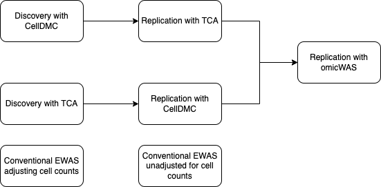

Figure 1: Workflow. Discovery: P = 1.42x10-8 (1x10-7 / 7), Replication: P = 0.05 / N hits AND effect estimate in same direction.

## Methods

We used ARIES 15up samples and defined teenage AD using parental questionnaire data, where the parent was asked whether their child had eczema within the last 12 months. This question was asked at 3 timepoints: 16y 6m, 13y 10m, 13y 1m. If “Yes” was answered to any of these questions they were deemed a case, regardless of whether they had been to a doctor. This gave us 328 cases and 1312 controls after QC.

DNAm data was taken from the 15up timepoint and measured using the EPIC array. 737075 CpG sites remained after QC.

### Models

1. DNAm ~ AD + sex + age + surrogate variables
2. DNAm ~ AD + sex + surrogate variables + cell counts

Other variables needed? - Genetic principal components weren’t used because lots of individuals would be removed as they don’t have genotype data

Note: Model 2 is only for the conventional EWAS

## Results

There were 78 sites within 10 cells that were identified by CellDMC and TCA. Of these, 40 replicated when using omicWAS (see table below). In the conventional EWAS, 0 CpG sites associated with AD when adjusting for cell counts and 0 associated when not adjusting for cell counts. **Figures 2 and 3** show the QQ plots and Manhattan plots for the CellDMC and TCA EWAS.

| Method | Cell type | CpG | Beta | P |
| --- | --- | --- | --- | --- |
| TCA | Bas | cg07649491 | -0.07345 | 1.8e-09 |
| CellDMC | Bas | cg07649491 | -0.07503 | 1.1e-09 |
| omicWAS | Bas | cg07649491 | -0.02083 | 3.3e-03 |
| TCA | Bas | cg22732812 | -0.15987 | 3.7e-09 |
| CellDMC | Bas | cg22732812 | -0.16411 | 1.2e-09 |
| omicWAS | Bas | cg22732812 | -0.07912 | 7.9e-04 |
| TCA | Bmem | cg02186441 | 0.27281 | 6.5e-09 |
| CellDMC | Bmem | cg02186441 | 0.27093 | 9.5e-10 |
| omicWAS | Bmem | cg02186441 | 0.15364 | 1.3e-04 |
| TCA | Bmem | cg02482566 | -0.60975 | 4.4e-10 |

[output cut: 227 more lines]

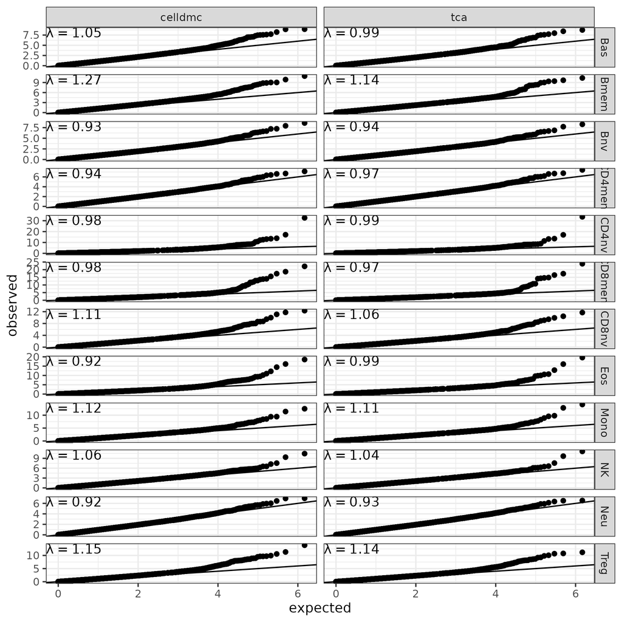

Figure 2: CellDMC and TCA QQ plots

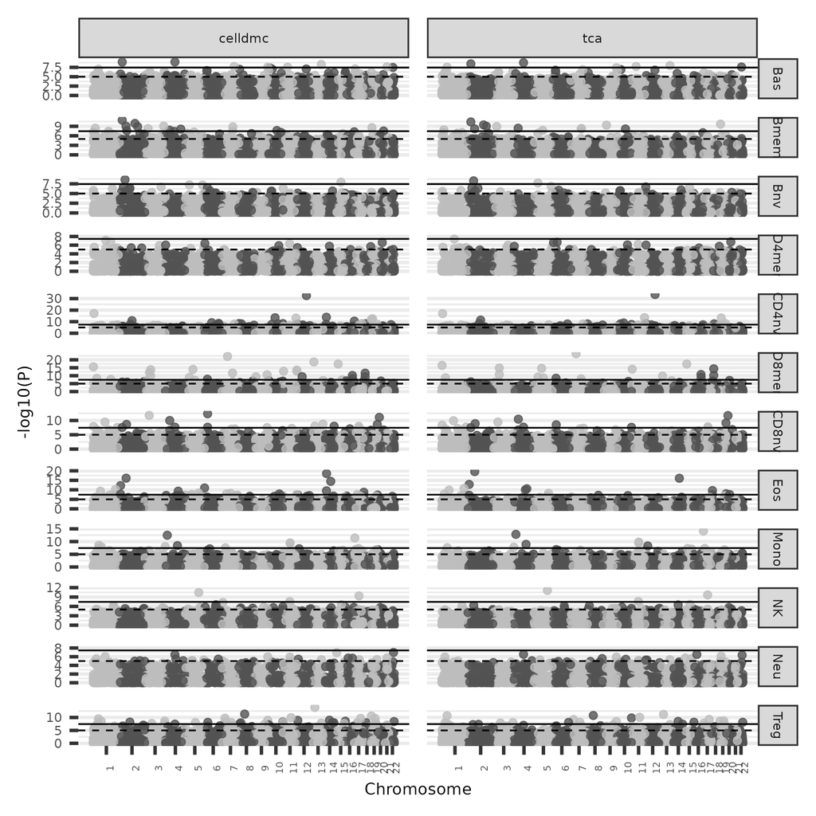

Figure 3: CellDMC and TCA manhattan plots